# TUGAS 67 MPDW

Adisti Suci Rahmah

2023-10-10

## Packages

```r
library(ggplot2)
library(tsibble)
library(tseries)
library(MASS)
library(forecast)
library(TSA)
library(TTR)
library(aTSA)
library(graphics)
```

## Data Asli

```r
datahujan<-read.csv("D:\\S1 STATISTIKA\\SEMESTER 5\\MPDW\\mpdw\\praktikum\\datahujan.csv",header=T)
datahujan.ts<-ts(datahujan$total_rainfall)
```

### Eksplorasi Data

#### Plot Data Penuh

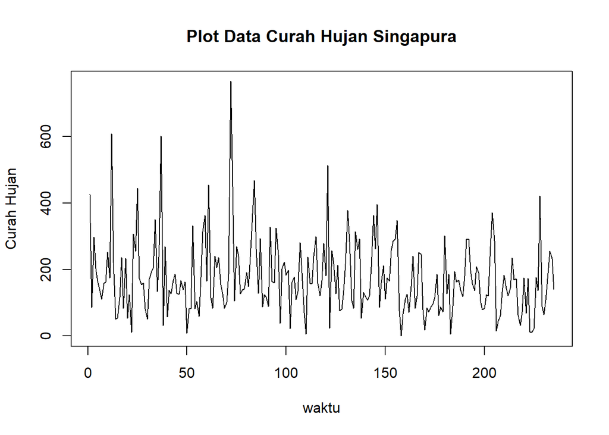

```r
plot.ts(datahujan.ts, lty=1, xlab="waktu", ylab="Curah Hujan", main="Plot Data Curah Hujan Singapura")
```

#### Plot Data Latih

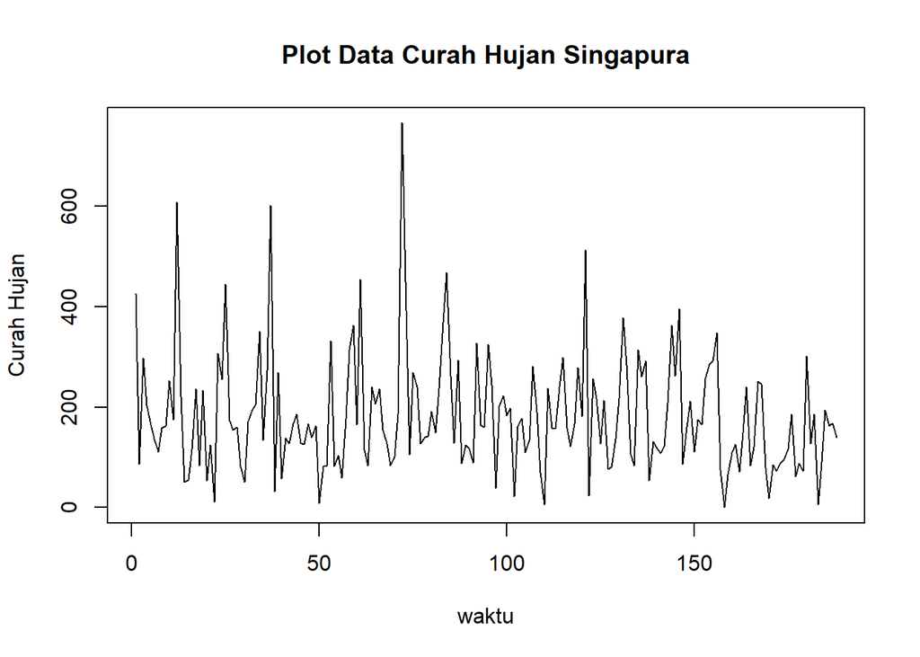

```r
hujantrain<-datahujan.ts[1:188]
train.ts<-ts(hujantrain)
plot.ts(train.ts, lty=1, xlab="waktu", ylab="Curah Hujan", main="Plot Data Curah Hujan Singapura")
```

Berdasarkan plot data deret waktu pada data latih, terlihat bahwa data cenderung bergerak pada nilai tengah tertentu. Hal ini mengindikasikan bahwa data stasioner dalam nilai tengah dan rataan.

#### Plot Data Uji

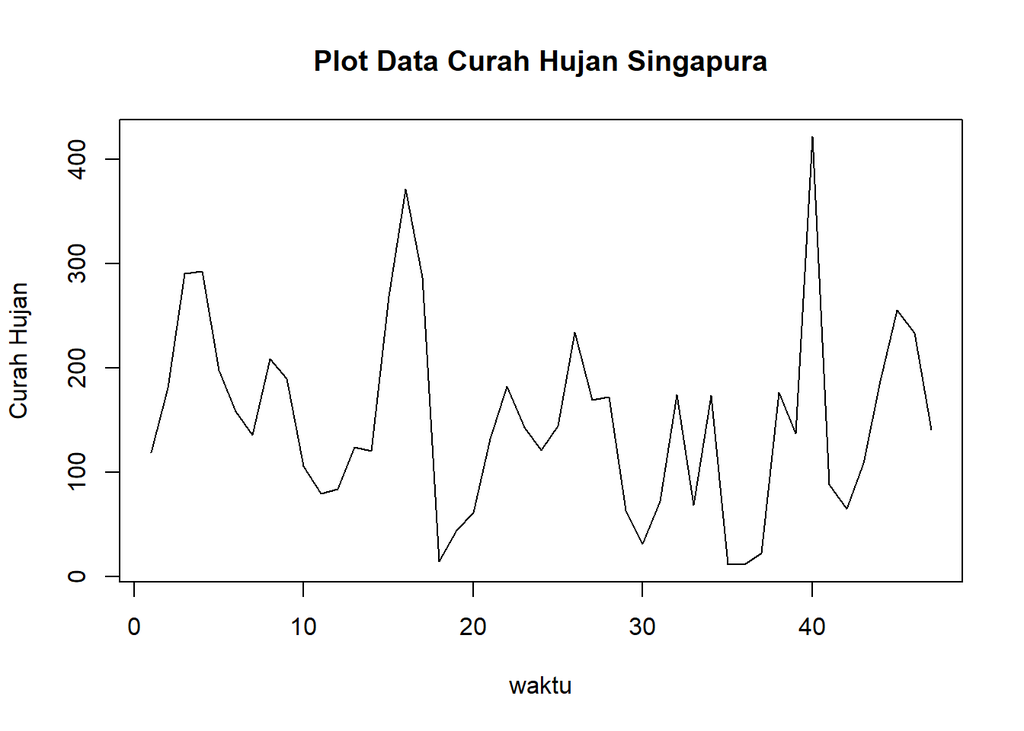

```r
hujantest<-datahujan.ts[189:235]
test.ts<-ts(hujantest)
plot.ts(test.ts, lty=1, xlab="waktu", ylab="Curah Hujan", main="Plot Data Curah Hujan Singapura")
```

### Uji Stasioneritas Data

#### Plot ACF

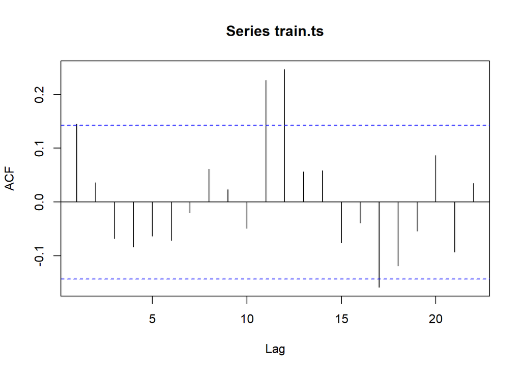

```r
acf(train.ts)
```

Berdasarkan plot ACF, terlihat bahwa plot ACF *tails of* membentuk gelombang sinus. Hal ini juga menjadi indikasi bahwa data stasioner dalam rataan

#### Uji ADF

```r
tseries::adf.test(train.ts)
```

```
##
##  Augmented Dickey-Fuller Test
##
## data:  train.ts
## Dickey-Fuller = -6.4448, Lag order = 5, p-value = 0.01
## alternative hypothesis: stationary
```

$H_0$ : Data tidak stasioner dalam rataan

$H_1$ : Data stasioner dalam rataan

Berdasarkan uji ADF tersebut, didapat *p-value* sebesar 0.01 yang lebih kecil dari taraf nyata 5% sehingga tolak $H_0$ dan menandakan bahwa data stasioner dalam rataan. Hal ini sesuai dengan hasil eksplorasi menggunakan plot time series dan plot ACF.

#### Plot Box-Cox

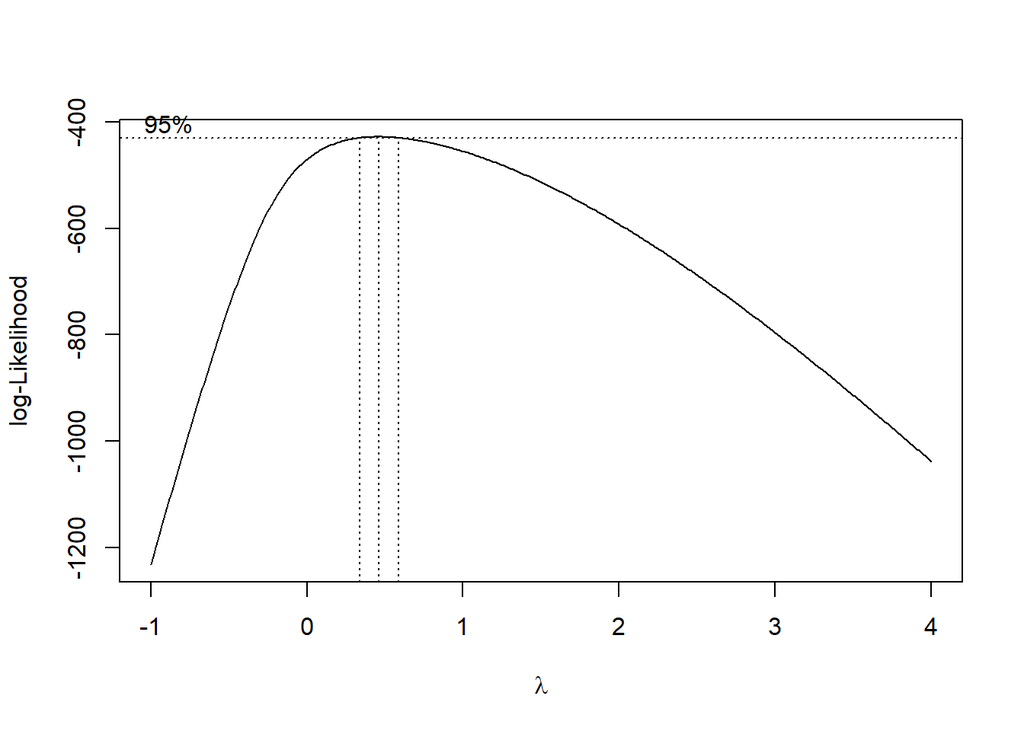

```r
index <- seq(1:188)
bc = boxcox(train.ts~index, lambda = seq(-1,4,by=0.01))
```

```r
#Nilai Rounded Lambda
lambda <- bc$x[which.max(bc$y)]
lambda
```

```
## [1] 0.46
```

```r
#SK
bc$x[bc$y > max(bc$y) - 1/2 * qchisq(.95,1)]
```

```
##  [1] 0.34 0.35 0.36 0.37 0.38 0.39 0.40 0.41 0.42 0.43 0.44 0.45 0.46 0.47 0.48
## [16] 0.49 0.50 0.51 0.52 0.53 0.54 0.55 0.56 0.57 0.58
```

### Identifikasi Model

#### Plot EACF

```r
eacf(train.ts)
```

```
## AR/MA
##   0 1 2 3 4 5 6 7 8 9 10 11 12 13
## 0 o o o o o o o o o o x  x  o  o
## 1 o o o o o o o o o o o  x  o  o
## 2 x x o o o o o o o o o  x  o  o
## 3 x o o o o o o o o o o  x  o  o
## 4 x x o o o o o o o o o  x  o  o
## 5 x x o o o o o o o o o  x  o  o
## 6 x x x o o o o o o o o  x  o  x
## 7 x x o o o o o o o o o  x  o  o
```

Identifikasi model menggunakan plot EACF dilakukan dengan melihat ujung segitiga pada pola segitiga nol. Dalam hal ini model tentatif yang terbentuk adalah ARIMA(1,0,1), ARIMA(1,0,2), dan ARIMA(2,0,2).

### Pendugaan Parameter Model Tentatif

#### ARIMA(1,0,1)

```r
model1.da=Arima(train.ts, order=c(1,0,1),method="ML")
summary(model1.da) #AIC=2328.37
```

```
## Series: train.ts
## ARIMA(1,0,1) with non-zero mean
##
## Coefficients:
##          ar1      ma1      mean
##       0.1923  -0.0453  182.4313
## s.e.  0.3355   0.3379    9.9767
##
## sigma^2 = 13636:  log likelihood = -1160.19
## AIC=2328.37   AICc=2328.59   BIC=2341.32
##
## Training set error measures:
##                      ME    RMSE      MAE       MPE     MAPE      MASE
## Training set -0.2103925 115.839 85.83187 -538.1069 562.8863 0.7826869
##                      ACF1
## Training set -0.003346353
```

```r
lmtest::coeftest(model1.da) #1 parameter signifikan
```

```
##
## z test of coefficients:
##
##             Estimate Std. Error z value Pr(>|z|)
## ar1         0.192277   0.335457  0.5732   0.5665
## ma1        -0.045255   0.337931 -0.1339   0.8935
## intercept 182.431345   9.976738 18.2857   <2e-16 ***
## ---
## Signif. codes:  0 '***' 0.001 '**' 0.01 '*' 0.05 '.' 0.1 ' ' 1
```

#### ARIMA(1,0,2)

```r
model2.da=Arima(train.ts, order=c(1,0,2),method="ML")
summary(model2.da) #AIC=2329.97
```

```
## Series: train.ts
## ARIMA(1,0,2) with non-zero mean
##
## Coefficients:
##           ar1     ma1     ma2      mean
##       -0.2420  0.3895  0.0961  182.4272
## s.e.   0.6859  0.6801  0.1130   10.0845
##
## sigma^2 = 13681:  log likelihood = -1159.98
## AIC=2329.97   AICc=2330.3   BIC=2346.15
##
## Training set error measures:
##                     ME     RMSE      MAE       MPE     MAPE      MASE
## Training set -0.206744 115.7127 86.08605 -544.2725 569.2433 0.7850047
##                      ACF1
## Training set -0.003449903
```

```r
lmtest::coeftest(model2.da) #1 parameter signifikan
```

```
##
## z test of coefficients:
##
##            Estimate Std. Error z value Pr(>|z|)
## ar1        -0.24195    0.68593 -0.3527   0.7243
## ma1         0.38946    0.68006  0.5727   0.5669
## ma2         0.09609    0.11304  0.8501   0.3953
## intercept 182.42719   10.08450 18.0899   <2e-16 ***
## ---
## Signif. codes:  0 '***' 0.001 '**' 0.01 '*' 0.05 '.' 0.1 ' ' 1
```

#### ARIMA(2,0,2)

```r
model3.da=Arima(train.ts, order=c(2,0,2),method="ML")
summary(model3.da) #AIC=2323.3
```

```
## Series: train.ts
## ARIMA(2,0,2) with non-zero mean
##
## Coefficients:
##           ar1      ar2     ma1     ma2      mean
##       -0.4387  -0.8762  0.5442  0.9999  182.1621
## s.e.   0.0537   0.0450  0.0388  0.0412    8.9550
##
## sigma^2 = 12829:  log likelihood = -1155.65
## AIC=2323.3   AICc=2323.76   BIC=2342.72
##
## Training set error measures:
##                     ME     RMSE      MAE       MPE     MAPE      MASE
## Training set 0.0327253 111.7506 83.43702 -516.1481 540.7116 0.7608487
##                    ACF1
## Training set 0.06118787
```

```r
lmtest::coeftest(model3.da) #semua parameter signifikan
```

```
##
## z test of coefficients:
##
##             Estimate Std. Error  z value  Pr(>|z|)
## ar1        -0.438710   0.053673  -8.1737  2.99e-16 ***
## ar2        -0.876163   0.044986 -19.4765 < 2.2e-16 ***
## ma1         0.544200   0.038820  14.0186 < 2.2e-16 ***
## ma2         0.999920   0.041191  24.2754 < 2.2e-16 ***
## intercept 182.162139   8.954951  20.3421 < 2.2e-16 ***
## ---
## Signif. codes:  0 '***' 0.001 '**' 0.01 '*' 0.05 '.' 0.1 ' ' 1
```

Berdasarkan pendugaan parameter di atas, nilai AIC terkecil dimiliki oleh model ARIMA(2,0,2) dan parameter model ARIMA(2,0,2) semuanya juga signifikan sehingga model yang dipilih adalah model ARIMA(2,0,2).

### Analisis Sisaan

Model terbaik hasil identifikasi kemudian dicek asumsi sisaannya. Sisaan model ARIMA harus memenuhi asumsi normalitas, kebebasan sisaan, dan kehomogenan ragam. Diagnostik model dilakukan secara eksplorasi dan uji formal.

#### Eksplorasi Sisaan

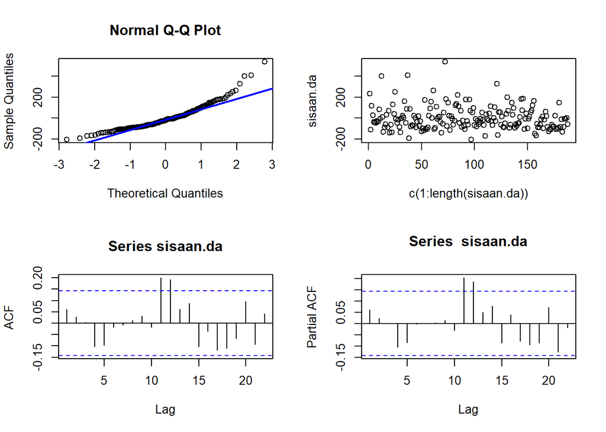

```r
#Eksplorasi
sisaan.da <- model3.da$residuals
par(mfrow=c(2,2))
qqnorm(sisaan.da)
qqline(sisaan.da, col = "blue", lwd = 2)
plot(c(1:length(sisaan.da)),sisaan.da)
acf(sisaan.da)
pacf(sisaan.da)
```

```r
par(mfrow = c(1,1))
```

#### Uji Formal

```r
#1) Sisaan Menyebar Normal
ks.test(sisaan.da,"pnorm")  #tolak H0 < sisaan menyebar normal
```

```
##
##  Asymptotic one-sample Kolmogorov-Smirnov test
##
## data:  sisaan.da
## D = 0.59005, p-value < 2.2e-16
## alternative hypothesis: two-sided
```

Selain dengan eksplorasi, asumsi tersebut dapat diuji menggunakan uji formal. Pada tahapan ini uji formal yang digunakan untuk normalitas adalah uji Kolmogorov-Smirnov (KS). Hipotesis pada uji KS adalah sebagai berikut.

$H_0$ : Sisaan menyebar normal

$H_1$ : Sisaan tidak menyebar normal

```r
#2) Sisaan saling bebas/tidak ada autokorelasi
Box.test(sisaan.da, type = "Ljung")  #tak tolak H0 > sisaan saling bebas
```

```
##
##  Box-Ljung test
##
## data:  sisaan.da
## X-squared = 0.71516, df = 1, p-value = 0.3977
```

Selanjutnya akan dilakukan uji formal untuk kebebasan sisaan menggunakan uji Ljung-Box. Hipotesis yang digunakan adalah sebagai berikut.

$H_0$ : Sisaan saling bebas

$H_1$ : Sisaan tidak tidak saling bebas

```r
#3) Sisaan homogen
Box.test((sisaan.da)^2, type = "Ljung")  #tolak H0 < sisaan homogen
```

```
##
##  Box-Ljung test
##
## data:  (sisaan.da)^2
## X-squared = 0.18553, df = 1, p-value = 0.6667
```

Hipotesis yang digunakan untuk uji kehomogenan ragam adalah sebagai berikut.

$H_0$ : Ragam sisaan homogen

$H_1$ : Ragam sisaan tidak homogen

Berdasarkan uji Ljung-Box terhadap sisaan kuadrat tersebut, didapat *p-value* sebesar 0.6667 yang lebih dari taraf nyata 5% sehingga tak tolak $H_0$ dan menandakan bahwa ragam sisaan homogen.

```r
#4) Nilai tengah sisaan sama dengan nol
t.test(sisaan.da, mu = 0, conf.level = 0.95)  #tak tolak h0 > nilai tengah sisaan sama dengan 0
```

```
##
##  One Sample t-test
##
## data:  sisaan.da
## t = 0.0040046, df = 187, p-value = 0.9968
## alternative hypothesis: true mean is not equal to 0
## 95 percent confidence interval:
##  -16.08845  16.15390
## sample estimates:
## mean of x
## 0.0327253
```

Terakhir, dengan uji-t, akan dicek apakah nilai tengah sisaan sama dengan nol. Hipotesis yang diujikan sebagai berikut.

$H_0$ : nilai tengah sisaan sama dengan 0

$H_1$ : nilai tengah sisaan tidak sama dengan 0

Berdasarkan uji-ttersebut, didapat *p-value* sebesar 0.9968 yang lebih besar dari taraf nyata 5% sehingga tak tolak $H_0$ dan menandakan bahwa nilai tengah sisaan sama dengan nol. Hal ini sama dengan eksplorasi.

### Peramalan

Peramalan dilakukan menggunakan fungsi `forecast()` . Contoh peramalan berikut ini dilakukan untuk 30 hari ke depan.

```r
#---FORECAST---#
ramalan.da <- forecast::forecast(model3.da, h = 30)
ramalan.da
```

```
##     Point Forecast    Lo 80    Hi 80     Lo 95    Hi 95
## 189       182.8849 37.04497 328.7249 -40.15805 405.9279
## 190       161.5882 14.97812 308.1983 -62.63258 385.8090
## 191       190.5548 43.60324 337.5064 -34.18823 415.2979
## 192       196.5063 48.50676 344.5058 -29.83946 422.8520
## 193       168.5159 20.51562 316.5161 -57.83097 394.8627
## 194       175.5811 26.73047 324.4317 -52.06629 403.2285
## 195       197.0057 48.03610 345.9753 -30.82364 424.8350
## 196       181.4162 32.02050 330.8119 -47.06480 409.8972
## 197       169.4840 19.74038 319.2277 -59.52912 398.4972
## 198       188.3777 38.53786 338.2176 -40.78257 417.5380
## 199       190.5434 40.27648 340.8103 -39.27001 420.3568
## 200       173.0393 22.77359 323.3051 -56.77230 402.8510
## 201       178.8211 28.23492 329.4072 -51.48058 409.1227
## 202       191.6210 40.96813 342.2738 -38.78267 422.0246
```

[output cut: 16 more lines]

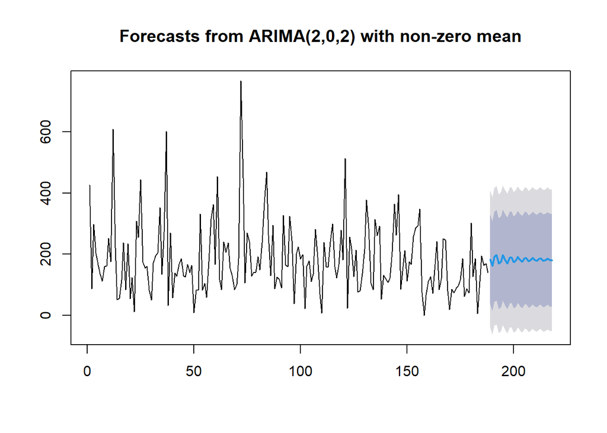

```r
data.ramalan.da <- ramalan.da$mean
plot(ramalan.da)
```

Berdasarkan hasil plot ramalan di atas, dapat dilihat bahwa ramalan ARIMA(2,0,2) cenderung stabil hingga akhir periode.

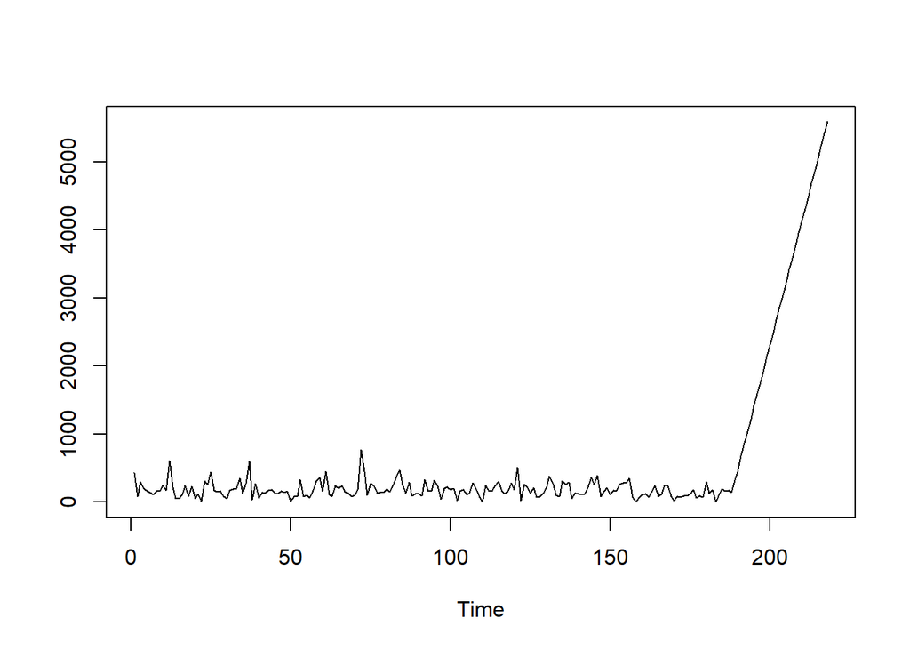

```r
pt_1 <- train.ts[188] #nilai akhir data latih
hasil.forc.Diff <- data.ramalan.da
hasil <- diffinv(hasil.forc.Diff, differences = 1) + pt_1

#has.1 sama hasilnta dengan: cumsum(c(pt_1,hasil.forc.Diff))
ts.plot(train.ts,hasil)
```

```r
perbandingan.da<-matrix(data=c(head(test.ts, n=30), hasil[-1]),
                     nrow = 30, ncol = 2)
colnames(perbandingan.da)<-c("Aktual","Hasil Forecast")
perbandingan.da
```

```
##       Aktual Hasil Forecast
##  [1,]  118.9       322.0849
##  [2,]  181.0       483.6732
##  [3,]  290.2       674.2280
##  [4,]  292.6       870.7343
##  [5,]  197.6      1039.2501
##  [6,]  158.4      1214.8312
##  [7,]  136.2      1411.8369
##  [8,]  208.6      1593.2531
##  [9,]  190.0      1762.7371
## [10,]  106.0      1951.1149
## [11,]   79.6      2141.6582
## [12,]   84.2      2314.6976
## [13,]  124.4      2493.5186
## [14,]  120.8      2685.1396
```

[output cut: 16 more lines]

```r
accuracy(ts(hasil[-1]), head(test.ts, n=30))
```

```
##                 ME     RMSE      MAE       MPE     MAPE      ACF1 Theil's U
## Test set -2796.549 3223.146 2796.549 -3447.026 3447.026 0.8990016  88.32686
```

Didapati bahwa nilai MAPE mencapai 3447.026